# PCA

## Workflow

```r
bmi_workflow2 <-
        workflow() %>%
        add_model(linear_model) %>%
        add_recipe(pca_reg_recipe2)

bmi_workflow2
```

```
## ══ Workflow ════════════════════════════════════════════════════════════════════
## Preprocessor: Recipe
## Model: linear_reg()
##
## ── Preprocessor ────────────────────────────────────────────────────────────────
## 3 Recipe Steps
##
## • step_scale()
## • step_center()
## • step_pca()
##
## ── Model ───────────────────────────────────────────────────────────────────────
## Linear Regression Model Specification (regression)
##
## Computational engine: glm
```

## Fit a Model

```r
bmi_fit2 <-
  bmi_workflow2 %>%
  fit(data = train_data)
```

```r
bmi_fit_extract2 <- bmi_fit2 %>%
                    extract_fit_parsnip() %>%
                    tidy()
bmi_fit_extract2
```

```
## # A tibble: 15 × 5
##    term            estimate std.error statistic   p.value
##    <chr>              <dbl>     <dbl>     <dbl>     <dbl>
##  1 (Intercept)       27.6      0.469     58.9   0
##  2 SDC_GENDER2        0.494    0.0988     5.00  5.99e-  7
##  3 SDC_INCOME2       -0.153    0.515     -0.298 7.66e-  1
##  4 SDC_INCOME3       -0.368    0.479     -0.770 4.42e-  1
##  5 SDC_INCOME4       -0.422    0.475     -0.888 3.74e-  1
##  6 SDC_INCOME5       -0.518    0.474     -1.09  2.74e-  1
##  7 SDC_INCOME6       -0.480    0.473     -1.02  3.10e-  1
##  8 SDC_INCOME7       -0.614    0.483     -1.27  2.04e-  1
##  9 SDC_INCOME8       -0.613    0.491     -1.25  2.12e-  1
## 10 SMK_CIG_STATUS1    0.160    0.104      1.54  1.24e-  1
## 11 SMK_CIG_STATUS2    0.152    0.323      0.470 6.39e-  1
## 12 SMK_CIG_STATUS3   -0.179    0.204     -0.876 3.81e-  1
## 13 PC1               -0.641    0.0259   -24.7   1.88e-130
## 14 PC2               -2.43     0.0324   -75.1   0
## 15 PC3               -0.404    0.0356   -11.3   1.38e- 29
```

## Prediction on testing data

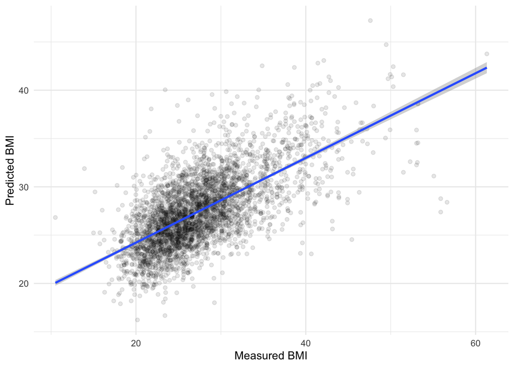

```r
bmi_predicted2 <- augment(bmi_fit2, test_data)

ggplot(bmi_predicted2, aes(x = PM_BMI_SR, y = .pred)) +
  geom_point(alpha = 0.1) +
  geom_smooth(method = "lm") +
  labs(x = "Measured BMI", y = "Predicted BMI") +
  theme_minimal()
```

Comparing the model performance (model with all components (model 1) vs model with only three components (model 2)) on testing data, both model perform poorly. However, the data points from model 1 graph (predicted vs measured) are more close to the line than the model 2 graph, which is expected given that model 1 contains all the components. The next approach of mine would be to use different component choosing methods present in the literature and then fit the model based on the decision of those methods and compare them to see which model performs better.